# Job-Suchdauer auf dem Arbeitsmarkt: Ein Machine Learning Ansatz

Statistik-Tage 2026

Simon Theurl & Stanislaus Stadlmann (AK Wien Datengruppe)

10.09.2026

# Einführung

## Einführung

- Projekt aus dem Beratungs-Alltag der AK Wien entstanden (Abteilung Rechtsschutz)
- Fragestellung: Lässt sich die Job-Suchdauer von arbeitslosen Personen (Ö) schätzen?
- Hintergrund: potentielle Anfechtung einer Kündigung vor Gericht mit der Begründung von Sozialwidrigkeit
- Sozialwidrigkeit: Unwahrscheinlich, dass Person bald einen Job findet (§ 105 ArbVG). Rechtssprechung deutet auf 9 Monate.

## Einführung II

**Beispiel**

- Arbeitnehmerin, 58 Jahre alt und mit 40%iger Behinderung arbeitet seit 1996 (30 Jahren) in Logistik-Betrieb.
- Kündigung wird ausgesprochen Ende letzten Jahres.
- Begründung: Wirtschaftlichkeit, allerdings: Das Unternehmen ist groß und sie könnte auch woanders Aufgaben übernehmen
- Gutachten: Kündigung wird zur Arbeitslosigkeit bis zur Pension führen
- Ausgang des Verfahrens: Vergleich wird geschlossen, Arbeitgeberin übernimmt 6-monatige Übergangs-Schulung für Ältere neue Arbeitslose.

## Einführung III

**Idee**

- Statistisches Modell aufstellen zur Berechnung der Wahrscheinlichkeit, dass AN länger als 9 Monate suchen wird.

**Nutzen eines Modells**

- *Rechtsschutz-Auswahl*: Bei kurzer erwarteter Job-Suchdauer ist ein positiver Ausgang des Verfahrens unwahrscheinlich.
- *Daten-basiertes Gegenargument zum Gutachten*: Gutachter:innen kommen oft zu sehr subjektiven Einschätzungen, denen man dann etwas entgegensetzen kann.

## Datensatz-Übersicht I

**Abhängige Variable**: - `u9`: Suchdauer unter 9 Monaten?

| **Prädiktor** | **Beschreibung** |
| --- | --- |
| start_month | Monat des Arbeitslosigkeits-Beginns |
| gesl | Geschlecht |
| alter | Alter |
| pre_nuts | NUTS, wo diese Person davor gearbeitet hat |
| be_dauer_pre | Dauer in Tagen, die diese Person in Beschäftigung war |
| pre_nace | In welcher Industrie hat diese Person gearbeitet? |
| total_duration_emp | Tage in Beschäftigung |

## Datensatz-Übersicht II

**Abhängige Variable**: - `u9`: Suchdauer unter 9 Monaten?

| **Prädiktor** | **Beschreibung** |
| --- | --- |
| cnt_emp | Anzahl der Beschäftigungsperioden |
| total_duration_ue | Tage in Arbeitslosigkeit |
| cnt_ue | Anzahl der Arbeitslosigkeits-Episoden |
| dauer_letzte_al | Dauer der letzten Arbeitslosigkeits-Episode in Tagen |
| zeit_seit_letzter_al | Zeit seit der letzten Arbeitslosigkeits-Episode in Tagen |
| krank_cnt | Anzahl der Krankenstände |
| krank_dauer | Gesamtdauer der Krankenstände in Tagen |

## Datensatz-Übersicht II

- n = **196.641**
- österreichische Versicherungsverläufe aus der Arbeitsmarkt-Datenbank (AMDB), (Arbeitsmarktservice Österreich (AMS) 2026a).
- Jahre: Training 2022-2024, Test 2025

## Explorative Statistik I

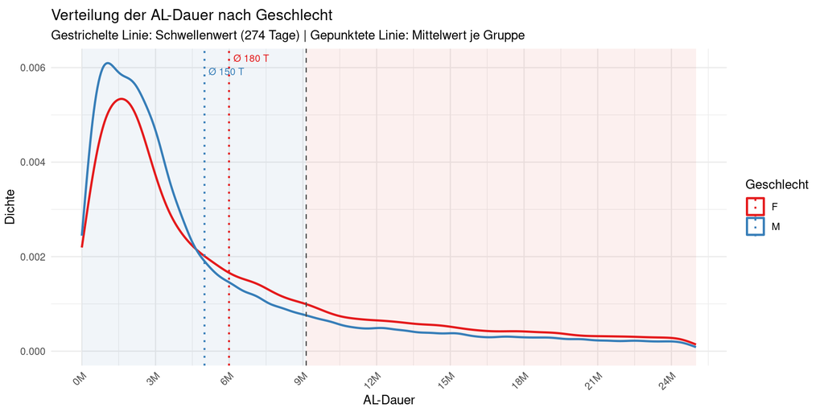

## Explorative Statistik II

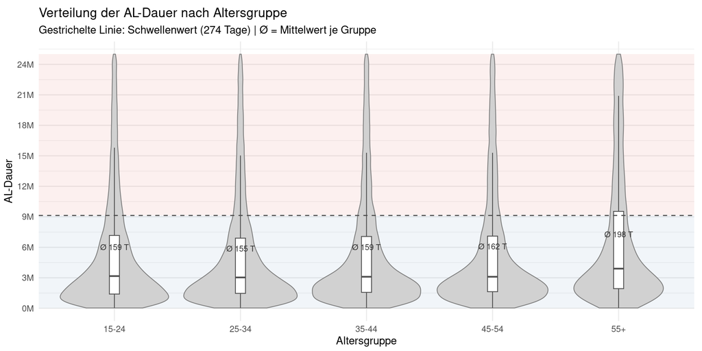

## Explorative Statistik III

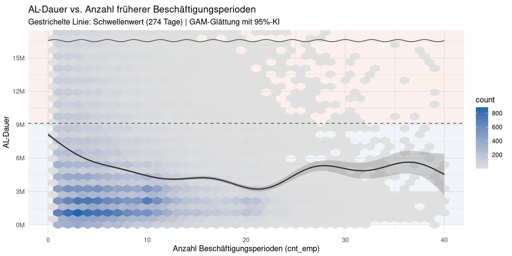

# Modell-Resultate

## Auswahl des Optimierungs-Kriteriums I

**Kriterien**

- Brier Score liegt nahe, durchschnittliche Abweichung der tatsächlichen und geschätzen Wahrscheinlichkeit:

$$BS={\frac {1}{N}}\sum \limits _{t=1}^{N}(f_{t}-o_{t})^{2}$$

wobei $f_t$ die vorhergesagte Wahrscheinlichkeit und $o_t$ der tatsächliche Outcome ist.

## Auswahl des Optimierungs-Kriteriums II

**Kriterien**

- Für die Klassifizierung ist allerdings Area Under the Receiver Operating Characteristic Curve (AUC-ROC) zu präferieren:

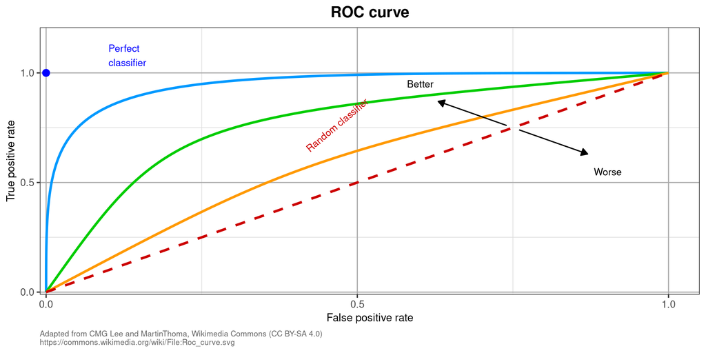

## Auswahl der Modelle

**Modelle**

- Random Forest (mit und ohne Tuning)
- Extreme Gradient Boosting (mit Tuning)
- Logit

## Ergebnisse

| Modell | Trainingsjahre | Testjahre | ROC-AUC | Brier-Score |
| --- | --- | --- | --- | --- |
| Logit | 2022-2024 | 2025 | 0.7637 (*0.7549) | 0.1798 (*0.1857) |
| Random Forest | 2022-2024 | 2025 | 0.7853 | 0.1727 |
| Random Forest - best | 2022-2024 | 2025 | 0.7880 (*0.7784) | 0.1719 (*0.1777) |
| XGBoost - best | 2022-2024 | 2025 | 0.7895 (*0.7796) | 0.1712 (*0.1773) |

* Ergebnis auf der Hold-out-Stichprobe (test_data)

- Mit einem AUROC von fast 0.8 ist das Modell sehr solide.

## Prognosemodell im internationalen Vergleich

| Country | Model | Outcome | ROC-AUC |
| --- | --- | --- | --- |
| Belgium (Flanders) | Statistical | unemployed >6 months | 0.702 |
| Finland | Statistical | unemployed >12 months | 0.80 |
| Germany | Statistical | unemployed >6 months | 0.7 |
| Germany | Statistical | unemployed >12 months | 0.777 |
| Ireland | Statistical | unemployed >12 months | 0.752 |
| United Kingdom | Statistical | unemployed >12 months | 0.795 |

Quelle: Junquera & Kern (2025)

## Feature Importance

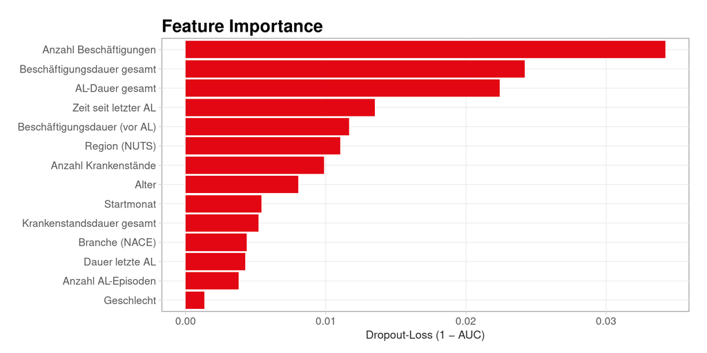

## Beispiel

- Arbeitnehmerin, 50 Jahre alt, arbeitet in den letzten 10 Jahren in 3 unterschiedlichen Betrieben in der Branche Arbeitskräfteüberlassung.
- Kündigung wird ausgesprochen am 11.04.2025.
- Gutachten: Klägerin wird mit hoher Wahrscheinlichkeit (80%) innerhalb von 6 bis 8 Monaten eine Vollzeitbeschäftigung finden.

| P(LZAL) | P(wieder BE) | Label |
| --- | --- | --- |
| 0.264 | 0.736 | reemployed |

# Ausblick

## Ausblick

- Kalibrierung der Modell-Wahrscheinlichkeiten (vor allem am Rand)
- Automatisiertes Rechnen/Tunen
- Neue Variablen: Gehalt, Job-Anzeigen
- Addition von Rechts-Zusatz (-20% Gehalts Einbußen)
- Implementierung in AK Infrastruktur mit kleiner internen Website
- PDF Export

## Autoren & Diskussion

- Simon Theurl (simon.theurl@akwien.at)
- Stanislaus Stadlmann (stanislaus.stadlmann@akwien.at)

QR Code zur Präsentation:

[figure not shown]

# Extra Folien

## Begrifflichkeiten

- **Vormerkdauer**: Zeitspanne zwischen Beginn der Arbeitslosigkeit aller aktuell arbeitslosen Personen und dem Statistik-Stichtag (Durchschnitt 231 Tage, Stand Mai 2026)
- **Verweildauer**: Zeitspanne, die zwischen dem Beginn und dem Ende einer Arbeitslosigkeit liegt (Durchschnitt 132 Tage, Stand Mai 2026). Unterbrechungen sind z.b. Auslandsaufenthalte > 28 Tage, Schulungen, etc.
- **Beschäftigungslosigkeits-Dauer**: Dauer zwischen zwei Beschäftigungen mit Voll-Versicherungen (2019: Durchschnitt 339 Tage). Es ist hierbei egal, was dazwischen passiert ist.

Quellen: (Arbeitsmarktservice Österreich (AMS) 2026b), (Arbeitsmarktservice Österreich (AMS) 2026a)

## Beispiel: Versicherungsverläufe

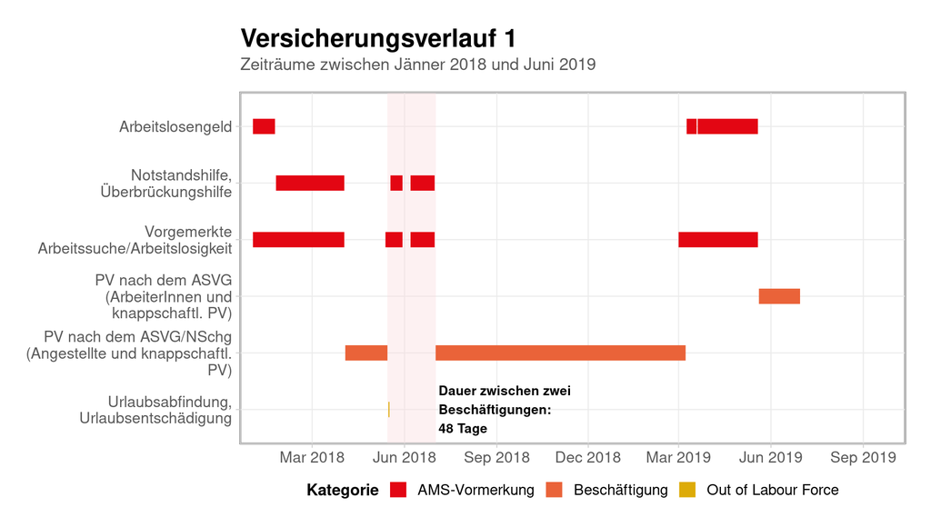

## Beispiel: Längere Beschäftigungslosigkeit

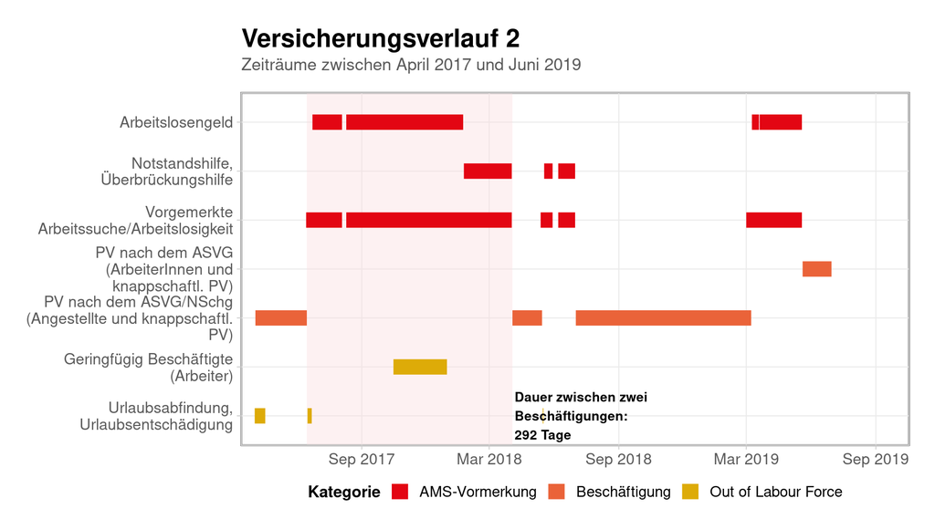

## Explorative Statistik - Anhang

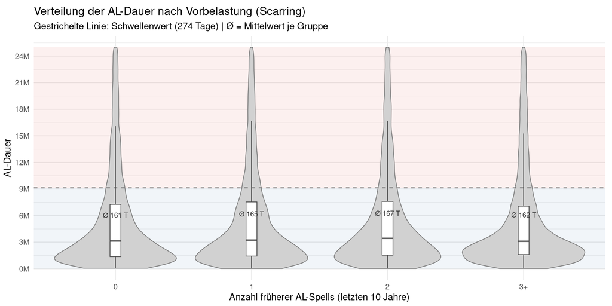

## Explorative Statistik - Anhang

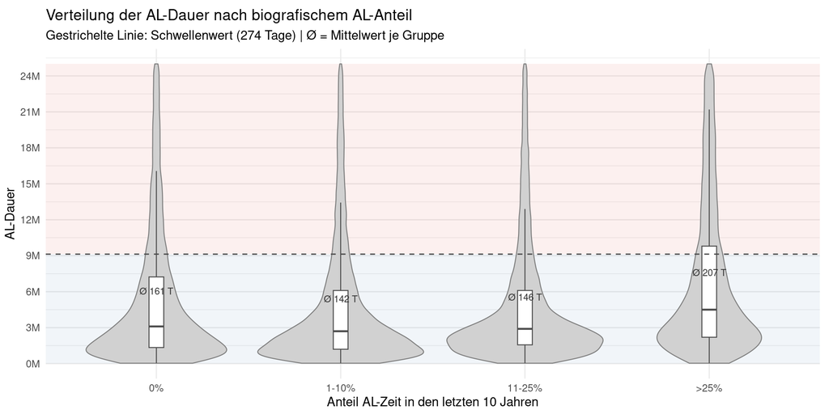

## Explorative Statistik - Anhang

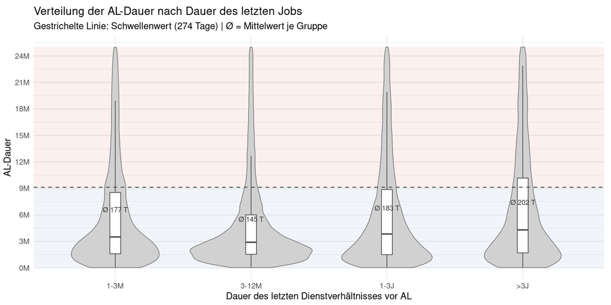

## Explorative Statistik - Anhang

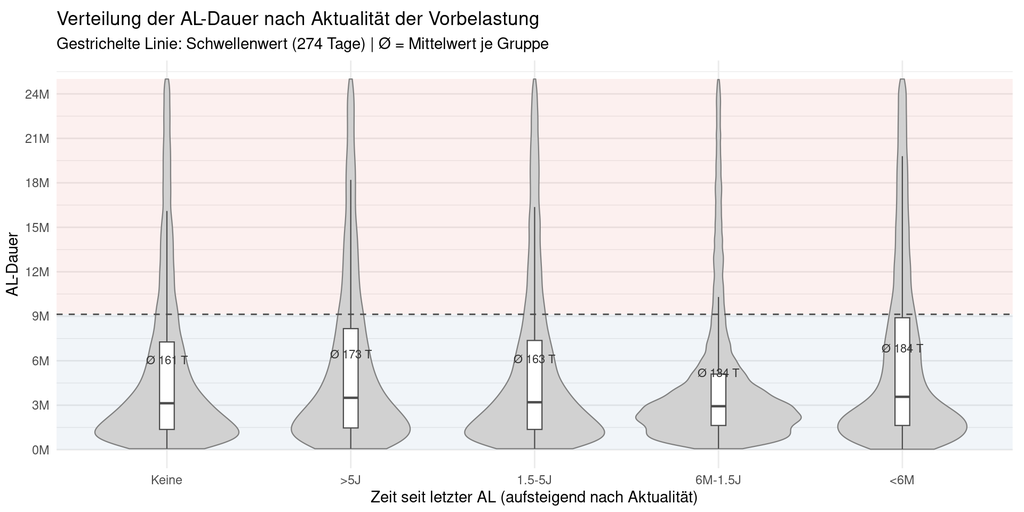